# Essentials of Data Analytics - Jcomp

### Building model after pruining:

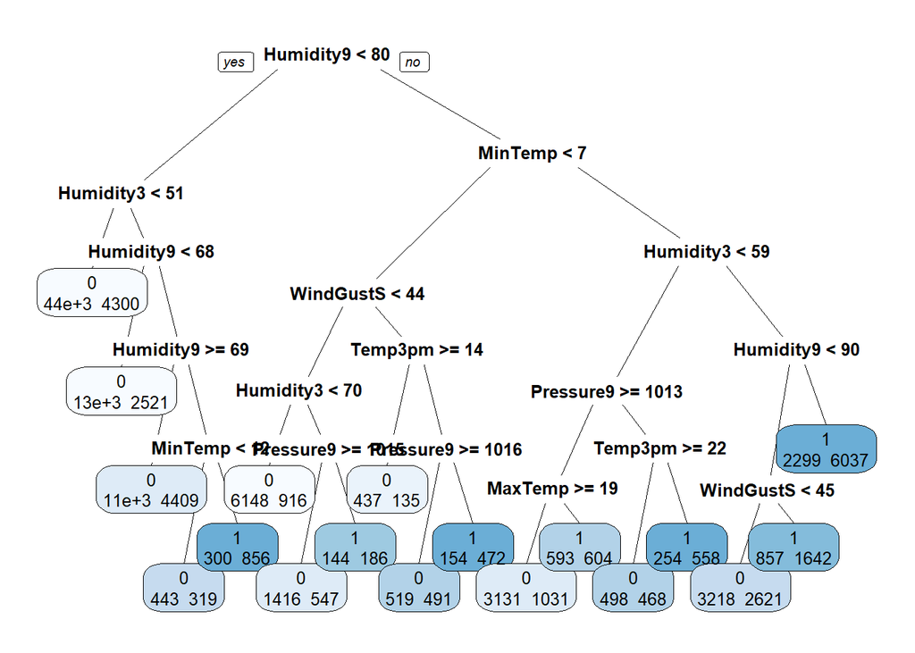

```r
bestcp <- model1$cptable[which.min(model1$cptable[,"xerror"]),"CP"]
pruned <- prune(model1, cp = bestcp)
prp(pruned, box.palette = "Blues",faclen = 0, cex = 0.8, extra = 1)
```

#### After pruining also, we got the same tree as of before.

### Accuracy after pruining

```r
pred <- pruned%>%predict(test_data,type="class")
mean(pred==test_data$RainToday)
```

```
## [1] 0.8034167
```

#### Since, both the trees are same the accuracy is also same i.e 80.34%

### Confusion matrix

```r
table(test_data$RainToday,pred_class)
```

[output not shown]

### Visualising Confusion matrix

[figure not shown]

```r
ctable <- as.table(matrix(c(20750, 1314, 4865, 2136), nrow = 2, byrow = TRUE))
plot1=fourfoldplot(ctable, color = c("#CC6666", "#99CC99"),
             conf.level = 0, margin = 1, main = "Confusion Matrix for Decision Tree")
```

## 3. K-Nearest Neighbour(KNN Algorithm)

#### The k-nearest neighbors (KNN) algorithm is a simple, easy-to-implement supervised machine learning algorithm that can be used to solve both classification and regression problems.

### Model Building

```r
prc_test_pred <- knn(train = train_data, test = test_data,cl = train_data$RainToday , k=1)
```

### Accuracy

```r
mean(prc_test_pred==test_data$RainToday)
```

```
## [1] 0.8635707
```

#### The accuracy of KNN model for k=1 is 86.35%

### Confusion Matrix

```r
table(test_data$RainToday,prc_test_pred)
```

```
##    prc_test_pred
##         0     1
##   0 20422  1642
##   1  2327  4701
```

### Visualising confusion matrix

[figure not shown]

```r
ctable <- as.table(matrix(c(20422, 1642, 2324, 4701), nrow = 2, byrow = TRUE))
plot1=fourfoldplot(ctable, color = c("#CC6666", "#99CC99"),
             conf.level = 0, margin = 1, main = "Confusion Matrix for KNN")
```

### Tuning the value of k

```r
i=1                          # declaration to initiate for loop
k.optm=1                     # declaration to initiate for loop
for (i in 1:7){
    knn.mod <-  knn(train = train_data, test = test_data,cl = train_data$RainToday , k=i)
    k.optm[i] <- 100 * sum(test_data$RainToday == knn.mod)/NROW(test_data$RainToday)
    k=i
    cat(k,'=',k.optm[i],'\n')       # to print % accuracy
}
```

```
## 1 = 86.35707
## 2 = 85.64554
## 3 = 88.447
## 4 = 88.12732
## 5 = 88.72542
## 6 = 88.38512
## 7 = 88.80448
```

#### Above table shows how accuracy, changes with ‘K’ value

### Visulising the best value of ‘k’

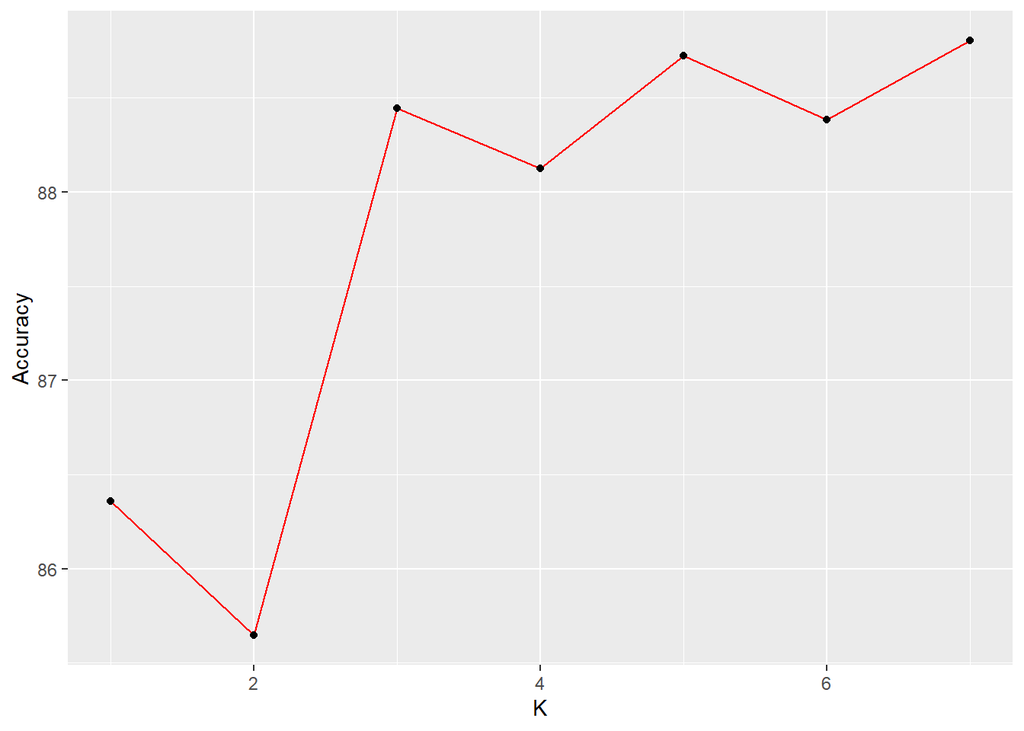

```r
k_values=seq(1,7, by=1)
temp_df=data.frame(k_values, k.optm)

ggplot(data=temp_df, aes(x=k_values, y=k.optm, group=1)) +
  geom_line(color="red")+
  geom_point()+
  ylab("Accuracy")+
  xlab("K")
```

#### From above plot, we can observe that K=7, we are getting highest accuracy.

# Effect of Rainfall on Agriculture in Australia

### Reading Dataset

```r
summercrop=read.csv("./AgriCultureData/SummerCropProduction.csv")
wintercrop=read.csv("./AgriCultureData/WinterCropProduction.csv")
```

### Structure of dataset

#### SummerCrop

```r
str(summercrop)
```

```
## 'data.frame':    32 obs. of  7 variables:
##  $ Year                      : chr  "1989–90" "1990–91" "1991–92" "1992–93" ...
##  $ New.South.Wales.Area      : int  481 464 543 488 517 524 574 655 635 914 ...
##  $ New.South.Wales.Production: int  1716 1612 2079 1612 1806 1869 2077 2653 2595 3227 ...
##  $ Queensland.Area           : int  440 578 658 515 651 761 846 747 692 810 ...
##  $ Queensland.Production     : int  941 995 1530 641 1214 1279 1535 1553 1186 1813 ...
##  $ Australia.Area            : int  932 1053 1212 1014 1183 1306 1434 1416 1341 1734 ...
##  $ Australia.Production      : int  2676 2625 3627 2280 3052 3187 3637 4240 3816 5065 ...
```

#### Top rows

```r
head(summercrop)
```

```
##      Year New.South.Wales.Area New.South.Wales.Production Queensland.Area
## 1 1989–90                  481                       1716             440
## 2 1990–91                  464                       1612             578
## 3 1991–92                  543                       2079             658
## 4 1992–93                  488                       1612             515
## 5 1993–94                  517                       1806             651
## 6 1994–95                  524                       1869             761
##   Queensland.Production Australia.Area Australia.Production
## 1                   941            932                 2676
## 2                   995           1053                 2625
## 3                  1530           1212                 3627
## 4                   641           1014                 2280
## 5                  1214           1183                 3052
## 6                  1279           1306                 3187
```

#### WinterCrop

```r
str(wintercrop)
```

```
## 'data.frame':    32 obs. of  8 variables:
##  $ Year             : chr  "1989–90" "1990–91" "1991–92" "1992–93" ...
##  $ Unit             : chr  "kt" "kt" "kt" "kt" ...
##  $ New.South.Wales  : chr  "4841" "5827" "3910" "5951" ...
##  $ Victoria         : chr  "3,343" "2,712" "2,815" "4,121" ...
##  $ Queensland       : chr  "1,829" "2,487" "462" "1,054" ...
##  $ South.Australia  : chr  "4,860" "3,901" "4,534" "4,798" ...
##  $ Western.Australia: chr  "6,606" "7,347" "7,183" "8,500" ...
##  $ Australia        : chr  "21,519" "22,326" "18,962" "24,487" ...
```

#### Top rows

```r
head(wintercrop)
```

```
##      Year Unit New.South.Wales Victoria Queensland South.Australia
## 1 1989–90   kt            4841    3,343      1,829           4,860
## 2 1990–91   kt            5827    2,712      2,487           3,901
## 3 1991–92   kt            3910    2,815        462           4,534
## 4 1992–93   kt            5951    4,121      1,054           4,798
## 5 1993–94   kt            7619    4,480        834           4,923
## 6 1994–95   kt            1528    1,864        312           3,044
##   Western.Australia Australia
## 1             6,606    21,519
## 2             7,347    22,326
## 3             7,183    18,962
## 4             8,500    24,487
## 5             9,873    27,797
## 6             7,924    14,719
```

## Data Cleaning

#### Converting year from chr to numeric of summercrop

```r
summercrop$Year=substr(summercrop$Year,1,4)
summercrop$Year=as.numeric(summercrop$Year)
str(summercrop)
```

```
## 'data.frame':    32 obs. of  7 variables:
##  $ Year                      : num  1989 1990 1991 1992 1993 ...
##  $ New.South.Wales.Area      : int  481 464 543 488 517 524 574 655 635 914 ...
##  $ New.South.Wales.Production: int  1716 1612 2079 1612 1806 1869 2077 2653 2595 3227 ...
##  $ Queensland.Area           : int  440 578 658 515 651 761 846 747 692 810 ...
##  $ Queensland.Production     : int  941 995 1530 641 1214 1279 1535 1553 1186 1813 ...
##  $ Australia.Area            : int  932 1053 1212 1014 1183 1306 1434 1416 1341 1734 ...
##  $ Australia.Production      : int  2676 2625 3627 2280 3052 3187 3637 4240 3816 5065 ...
```

```r
wintercrop$Year=substr(wintercrop$Year,1,4)
wintercrop$Year=as.numeric(wintercrop$Year)
wintercrop$New.South.Wales=as.numeric(gsub(",","",wintercrop$New.South.Wales))
wintercrop$Victoria=as.numeric(gsub(",","",wintercrop$Victoria))
wintercrop$Queensland=as.numeric(gsub(",","",wintercrop$Queensland))
wintercrop$South.Australia=as.numeric(gsub(",","",wintercrop$South.Australia))
wintercrop$Western.Australia=as.numeric(gsub(",","",wintercrop$Western.Australia))
wintercrop$Australia=as.numeric(gsub(",","",wintercrop$Australia))

str(wintercrop)
```

```
## 'data.frame':    32 obs. of  8 variables:
##  $ Year             : num  1989 1990 1991 1992 1993 ...
##  $ Unit             : chr  "kt" "kt" "kt" "kt" ...
##  $ New.South.Wales  : num  4841 5827 3910 5951 7619 ...
##  $ Victoria         : num  3343 2712 2815 4121 4480 ...
##  $ Queensland       : num  1829 2487 462 1054 834 ...
##  $ South.Australia  : num  4860 3901 4534 4798 4923 ...
##  $ Western.Australia: num  6606 7347 7183 8500 9873 ...
##  $ Australia        : num  21519 22326 18962 24487 27797 ...
```

#### Grouping location on the basis of the states they correspond to.

```r
agriculture_data=split_data
agriculture_data=agriculture_data%>%
  mutate(State=case_when(
    Location=="Albury" | Location=="BadgerysCreek" | Location=="Cobar" | Location=="CoffsHarbour" | Location=="Moree" | Location=="Newcastle" | Location=="NorahHead" | Location=="NorfolkIsland" | Location=="Penrith" | Location=="Richmond" | Location=="Sydney" | Location=="SydneyAirport" | Location=="WaggaWagga" | Location=="Williamtown" | Location=="Wollongong" | Location=="Canberra" ~"New South Wales",
    Location=="Tuggeranong" | Location=="MountGinini" | Location=="Ballarat" | Location=="Bendigo" | Location=="Sale" | Location=="MelbourneAirport" | Location=="Melbourne" | Location=="Mildura" | Location=="Nhil" | Location=="Portland" | Location=="Watsonia" | Location=="Dartmoor" ~"Victoria",
    Location=="Brisbane" | Location=="Cairns" | Location=="GoldCoast" | Location=="Townsville" ~ "Queensland",
    Location=="Adelaide" | Location=="MountGambier" | Location=="Nuriootpa" | Location=="Woomera" ~ "South Australia",
    Location=="Albany" | Location=="Witchcliffe" | Location=="PearceRAAF" | Location=="PerthAirport" | Location=="Perth" | Location=="SalmonGums" | Location=="Walpole" ~ "Western Australia",
    Location=="Hobart" | Location=="Hobart" | Location=="Launceston" | Location=="AliceSprings" | Location=="Darwin" | Location=="Katherine" | Location=="Uluru" ~ "Northern Territory"
  ))

str(agriculture_data)
```

```
## 'data.frame':    145460 obs. of  28 variables:
##  $ Date         : POSIXct, format: "2008-12-01" "2008-12-02" ...
##  $ Location     : chr  "Albury" "Albury" "Albury" "Albury" ...
##  $ MinTemp      : num  13.4 7.4 12.9 9.2 17.5 14.6 14.3 7.7 9.7 13.1 ...
##  $ MaxTemp      : num  22.9 25.1 25.7 28 32.3 29.7 25 26.7 31.9 30.1 ...
##  $ Rainfall     : num  0.6 0 0 0 1 0.2 0 0 0 1.4 ...
##  $ Evaporation  : num  5.47 5.47 5.47 5.47 5.47 ...
##  $ Sunshine     : num  7.61 7.61 7.61 7.61 7.61 ...
##  $ WindGustDir  : chr  "W" "WNW" "WSW" "NE" ...
##  $ WindGustSpeed: num  44 44 46 24 41 56 50 35 80 28 ...
##  $ WindDir9am   : chr  "W" "NNW" "W" "SE" ...
##  $ WindDir3pm   : chr  "WNW" "WSW" "WSW" "E" ...
##  $ WindSpeed9am : num  20 4 19 11 7 19 20 6 7 15 ...
##  $ WindSpeed3pm : num  24 22 26 9 20 24 24 17 28 11 ...
##  $ Humidity9am  : num  71 44 38 45 82 55 49 48 42 58 ...
##  $ Humidity3pm  : num  22 25 30 16 33 23 19 19 9 27 ...
##  $ Pressure9am  : num  1008 1011 1008 1018 1011 ...
##  $ Pressure3pm  : num  1007 1008 1009 1013 1006 ...
##  $ Cloud9am     : num  8 4.45 4.45 4.45 7 ...
##  $ Cloud3pm     : num  4.51 4.51 2 4.51 8 ...
##  $ Temp9am      : num  16.9 17.2 21 18.1 17.8 20.6 18.1 16.3 18.3 20.1 ...
##  $ Temp3pm      : num  21.8 24.3 23.2 26.5 29.7 28.9 24.6 25.5 30.2 28.2 ...
##  $ RainToday    : Factor w/ 2 levels "0","1": 1 1 1 1 1 1 1 1 1 2 ...
##  $ RainTomorrow : Factor w/ 2 levels "0","1": 1 1 1 1 1 1 1 1 2 1 ...
##  $ Day          : Ord.factor w/ 7 levels "Sun"<"Mon"<"Tue"<..: 2 3 4 5 6 7 1 2 3 4 ...
##  $ year         : num  2008 2008 2008 2008 2008 ...
##  $ mon          : num  12 12 12 12 12 12 12 12 12 12 ...
##  $ day          : num  1 2 3 4 5 6 7 8 9 10 ...
##  $ State        : chr  "New South Wales" "New South Wales" "New South Wales" "New South Wales" ...
```

## EDA

### Production of Winter Crop State-wise

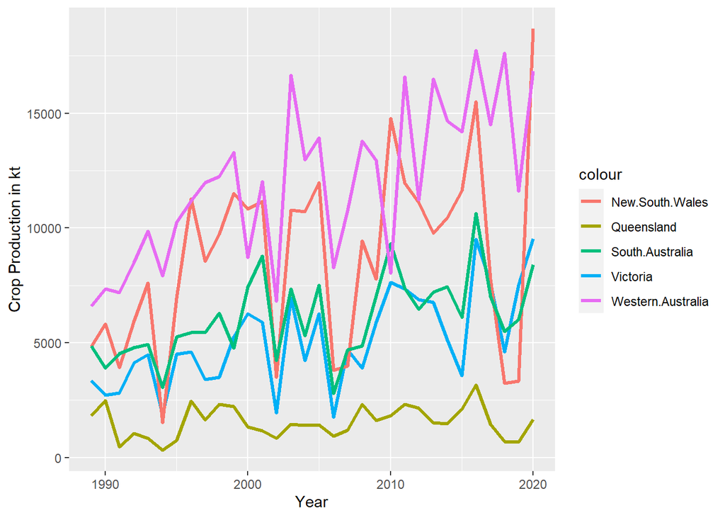

```r
ggplot(wintercrop, aes(Year)) +
  geom_line(aes(y = Victoria, colour = "Victoria"),size=1.2) +
  geom_line(aes(y = Queensland, colour = "Queensland"), size=1.2)+
  geom_line(aes(y = New.South.Wales, colour = "New.South.Wales"), size=1.2)+
  geom_line(aes(y = South.Australia, colour = "South.Australia"), size=1.2)+
  geom_line(aes(y = Western.Australia, colour = "Western.Australia"), size=1.2)+
  ylab("Crop Production in kt")+
  xlab("Year")
```

### Production of Summer Crop State-wise

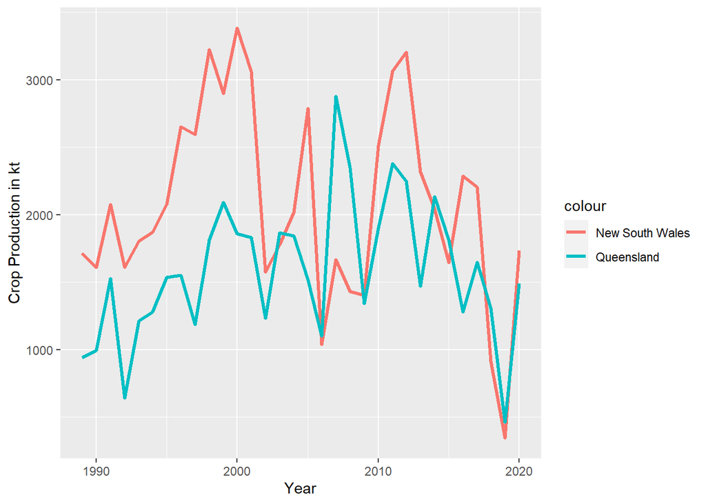

```r
ggplot(summercrop, aes(Year)) +
  geom_line(aes(y = New.South.Wales.Production, colour = "New South Wales"),size=1.2) +
  geom_line(aes(y = Queensland.Production, colour = "Queensland"), size=1.2)+
  ylab("Crop Production in kt")+
  xlab("Year")
```

#### The above line plot we can observe that there are only two states which have production in Summer Season.

### Visualisation of winter crop 2017 on Australian Map

#### Data Cleaning

```r
aus <- world.cities[world.cities$country.etc == "Australia",]

aus=aus%>%
  mutate(State=case_when(
    name=="Albury" | name=="BadgerysCreek" | name=="Cobar" | name=="CoffsHarbour" | name=="Moree" | name=="Newcastle" | name=="NorahHead" | name=="NorfolkIsland" | name=="Penrith" | name=="Richmond" | name=="Sydney" | name=="SydneyAirport" | name=="WaggaWagga" | name=="Williamtown" | name=="Wollongong" | name=="Canberra" ~"New South Wales",
    name=="Tuggeranong" | name=="MountGinini" | name=="Ballarat" | name=="Bendigo" | name=="Sale" | name=="MelbourneAirport" | name=="Melbourne" | name=="Mildura" | name=="Nhil" | name=="Portland" | name=="Watsonia" | name=="Dartmoor" ~"Victoria",
    name=="Brisbane" | name=="Cairns" | name=="GoldCoast" | name=="Townsville" ~ "Queensland",
    name=="Adelaide" | name=="MountGambier" | name=="Nuriootpa" | name=="Woomera" ~ "South Australia",
    name=="Albany" | name=="Witchcliffe" | name=="PearceRAAF" | name=="PerthAirport" | name=="Perth" | name=="SalmonGums" | name=="Walpole" ~ "Western Australia",
    name=="Hobart" | name=="Hobart" | name=="Launceston" | name=="AliceSprings" | name=="Darwin" | name=="Katherine" | name=="Uluru" ~ "Northern Territory"
  ))
```

#### Assigning values

```r
aus=aus%>%
  mutate(winter2017=case_when(
    State=="New South Wales"~7743,
    State=="Victoria"~7612,
    State=="Queensland"~1438,
    State=="South Australia"~7022,
    State=="Western Australia"~14510,
    State=="Northern Territory"~0
  ))

aus=aus%>%
  mutate(Rain2017=case_when(
    State=="New South Wales"~3.0582515,
    State=="Victoria"~1.4062729,
    State=="Queensland"~4.6504147,
    State=="South Australia"~1.1469991,
    State=="Western Australia"~1.7753573,
    State=="Northern Territory"~3.3233085
  ))
aus=na.omit(aus)
```

#### Plotting agriculture data on map for winter season production

```r
pal <- colorNumeric(palette = "Greens",
                    domain = aus$winter2017)

leaflet(data = aus) %>%
    addTiles() %>%
    addCircleMarkers(lat = ~lat, lng = ~long, popup = ~name,
                     color = ~pal(winter2017), stroke = FALSE, fillOpacity = 0.6) %>%
    addLegend(position = "bottomleft", pal = pal, values = ~winter2017)
```

[interactive chart not shown]

#### In the map we can observe, Eastern Aus has a large number of cities which are doing agriculture activities. But, the Western Aus has more production but less area for agriculture.

### Visualising Rain on Map

```r
pal <- colorNumeric(palette = "Blues",
                    domain = aus$Rain2017)
leaflet(data = aus) %>%
    addTiles() %>%
    addCircleMarkers(lat = ~lat, lng = ~long, popup = ~name,
                     color = ~pal(Rain2017), stroke = FALSE, fillOpacity = 0.6) %>%
    addLegend(position = "bottomleft", pal = pal, values = ~Rain2017)
```

[interactive chart not shown]

## How Rainfall Effects winter crops

### Selecting suitable rows

```r
winterRain=agriculture_data%>%
  filter(mon==6 | mon==7 | mon==8 | mon==9 | mon==10)

DatabyState=agriculture_data%>%
  group_by(year,State)%>%
  summarise(avgRain=mean(Rainfall), avgLight=mean(Sunshine))
DatabyState
```

```
## # A tibble: 61 x 4
## # Groups:   year [11]
##     year State              avgRain avgLight
##    <dbl> <chr>                <dbl>    <dbl>
##  1  2007 New South Wales       3.22     8.09
##  2  2008 New South Wales       2.22     7.61
##  3  2008 Northern Territory    2.00     8.00
##  4  2008 Queensland            4.01     8.26
##  5  2008 South Australia       1.84     7.50
##  6  2008 Victoria              1.91     6.92
##  7  2008 Western Australia     1.95     8.72
##  8  2009 New South Wales       2.22     7.76
##  9  2009 Northern Territory    2.35     8.15
## 10  2009 Queensland            4.48     8.13
## # ... with 51 more rows
```

#### Making data frame for winter production

```r
## New South Wales

temp=DatabyState%>%
  filter(State=="New South Wales", year>2007)

temp2=wintercrop%>%
  filter(Year>2007 & Year<2018)

NSW_production=temp2$New.South.Wales
temp1=cbind(temp,production=NSW_production)

## Queensland

temp=DatabyState%>%
  filter(State=="Queensland")

temp2=wintercrop%>%
  filter(Year>2007 & Year<2018)

NSW_production=temp2$New.South.Wales
temp02=cbind(temp,production=NSW_production)

## South Australia

temp=DatabyState%>%
  filter(State=="South Australia")

temp2=wintercrop%>%
  filter(Year>2007 & Year<2018)

NSW_production=temp2$New.South.Wales
temp3=cbind(temp,production=NSW_production)

## Victoria

temp=DatabyState%>%
  filter(State=="Victoria")

temp2=wintercrop%>%
  filter(Year>2007 & Year<2018)

NSW_production=temp2$New.South.Wales
temp4=cbind(temp,production=NSW_production)

## Western Australia

temp=DatabyState%>%
  filter(State=="Western Australia")

temp2=wintercrop%>%
  filter(Year>2007 & Year<2018)

NSW_production=temp2$New.South.Wales
temp5=cbind(temp,production=NSW_production)
```

### Converting data into time series

```r
ts_winter1=ts(temp1[,c(-1,-2,-4)], start=c(2008),end=c(2017), frequency = 1)
ts_winter2=ts(temp02[,c(-1,-2,-4)], start=c(2008),end=c(2017), frequency = 1)
ts_winter3=ts(temp3[,c(-1,-2,-4)], start=c(2008),end=c(2017), frequency = 1)
ts_winter4=ts(temp4[,c(-1,-2,-4)], start=c(2008),end=c(2017), frequency = 1)
ts_winter5=ts(temp5[,c(-1,-2,-4)], start=c(2008),end=c(2017), frequency = 1)
```

### Building Model(using VAR model)

```r
model1=vars::VAR(ts_winter1, type = "none", lag.max = 5, ic = "AIC")
model2=vars::VAR(ts_winter2, type = "none", lag.max = 5, ic = "AIC")
model3=vars::VAR(ts_winter3, type = "none", lag.max = 5, ic = "AIC")
model4=vars::VAR(ts_winter4, type = "none", lag.max = 5, ic = "AIC")
model5=vars::VAR(ts_winter5, type = "none", lag.max = 5, ic = "AIC")
```

### Forecasting production

```r
fc1 <- forecast(model1,level=c(95),h=1*5)
fc2 <- forecast(model2,level=c(95),h=1*5)
fc3 <- forecast(model3,level=c(95),h=1*5)
fc4 <- forecast(model4,level=c(95),h=1*5)
fc5 <- forecast(model5,level=c(95),h=1*5)
```

### Visualising the forecasted values

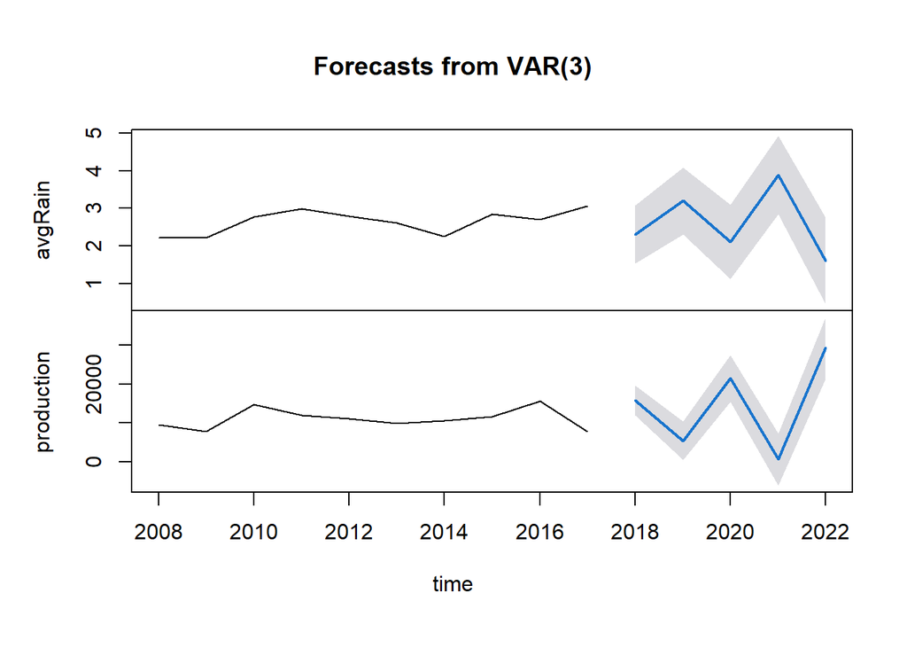

```r
plot(fc1)
```

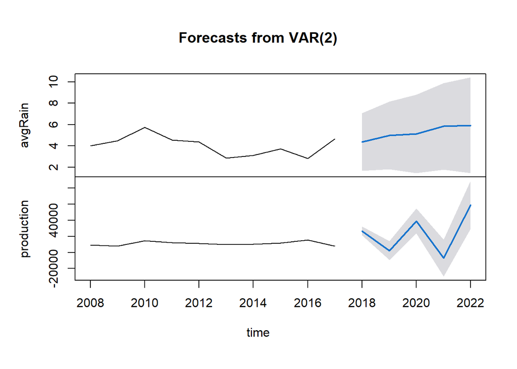

```r
plot(fc2)
```

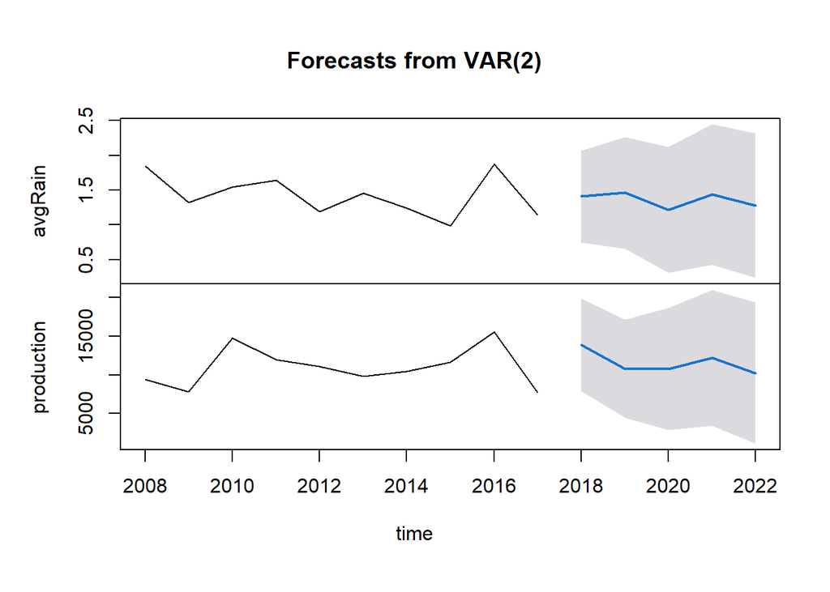

```r
plot(fc3)
```

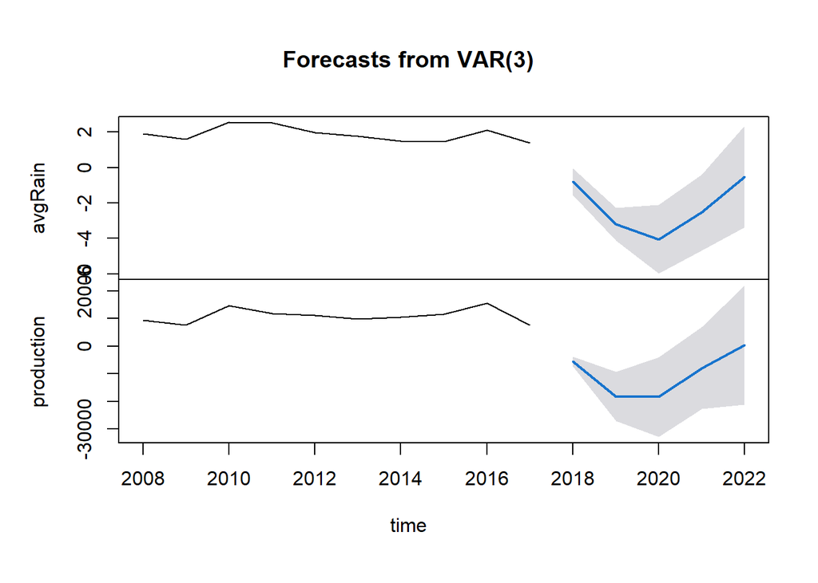

```r
plot(fc4)
```

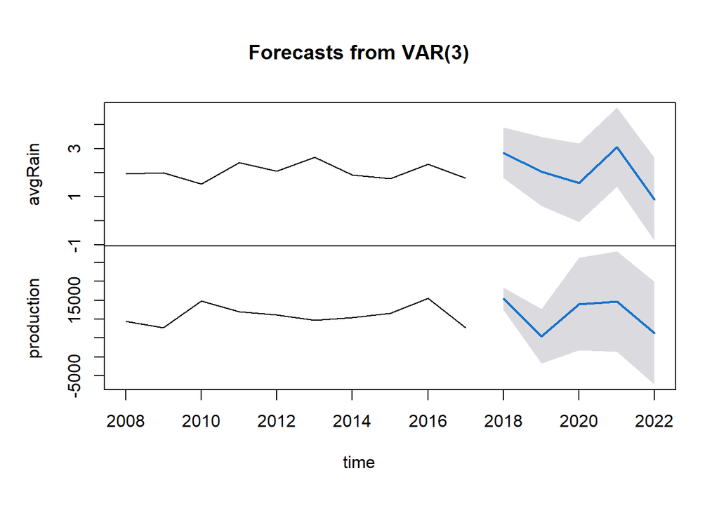

```r
plot(fc5)
```

#### From the above 5 plots, we can conclude that the overall production will increase, but in some regions the production will decrease in the upcoming years.

## How Rainfall Effects summer rows

```r
winterRain=agriculture_data%>%
  filter(mon==12 | mon==1 | mon==2 | mon==3 | mon==4)

DatabyState=agriculture_data%>%
  group_by(year,State)%>%
  summarise(avgRain=mean(Rainfall), avgLight=mean(Sunshine))
DatabyState
```

```
## # A tibble: 61 x 4
## # Groups:   year [11]
##     year State              avgRain avgLight
##    <dbl> <chr>                <dbl>    <dbl>
##  1  2007 New South Wales       3.22     8.09
##  2  2008 New South Wales       2.22     7.61
##  3  2008 Northern Territory    2.00     8.00
##  4  2008 Queensland            4.01     8.26
##  5  2008 South Australia       1.84     7.50
##  6  2008 Victoria              1.91     6.92
##  7  2008 Western Australia     1.95     8.72
##  8  2009 New South Wales       2.22     7.76
##  9  2009 Northern Territory    2.35     8.15
## 10  2009 Queensland            4.48     8.13
## # ... with 51 more rows
```

```r
## New South Wales

temp=DatabyState%>%
  filter(State=="New South Wales", year>2007)

temp2=summercrop%>%
  filter(Year>2007 & Year<2018)

NSW_production=temp2$New.South.Wales.Production
temp1=cbind(temp,production=NSW_production)

## Queensland

temp=DatabyState%>%
  filter(State=="Queensland")

temp2=summercrop%>%
  filter(Year>2007 & Year<2018)

NSW_production=temp2$Queensland.Production
temp02=cbind(temp,production=NSW_production)
```

### Converting data into time series

```r
ts_summer1=ts(temp1[,c(-1,-2,-4)], start=c(2008),end=c(2017), frequency = 1)
ts_summer2=ts(temp02[,c(-1,-2,-4)], start=c(2008),end=c(2017), frequency = 1)
```

### Building Model(using VAR model)

```r
model1=vars::VAR(ts_summer1, type = "none", lag.max = 5, ic = "AIC")
model2=vars::VAR(ts_summer2, type = "none", lag.max = 5, ic = "AIC")
```

### Forecasting production

```r
fc1 <- forecast(model1,level=c(95),h=1*5)
fc2 <- forecast(model2,level=c(95),h=1*5)
```

### Visualising the forecasted values

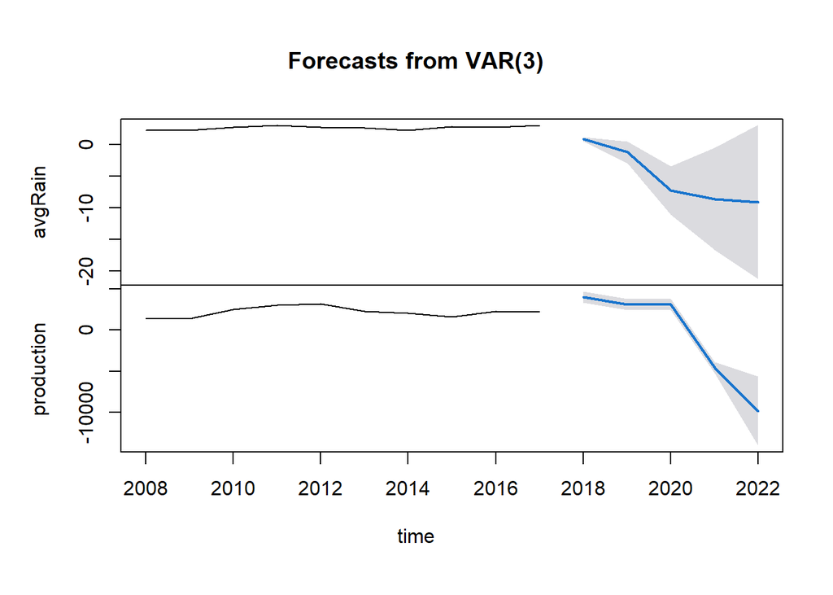

```r
plot(fc1)
```

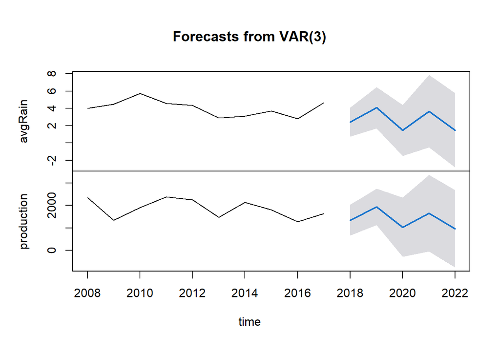

```r
plot(fc2)
```

#### From the above 2 plots, we can conclude that the overall production will decrease in the upcoming years for summer crops.

# END